# Assessment

2024-11-01

## Investigating seasonal trends in prescription of antidepressants in scotland in 2023- loading data

## Trends in the prescribing of SSRI’s across the four seasons – for instance, is there a spike in the winter season (SAD)?

## seasonal affective disorder (SAD) is a type of depression that comes and goes in a seasonal pattern - SSRIs are the first line of treatment for SAD. I want to analyse prescriptions of SSRIs in Scotland in 2023 to see if there is a spike in the winter season when SAD is prevalent.

```r
install.packages(c("tidyverse", "janitor", "gt", "here", "lubridate"))
library(tidyverse)
library(janitor)
library(gt)
library(here)
data_jan2023 <- read_csv("https://www.opendata.nhs.scot/dataset/84393984-14e9-4b0d-a797-b288db64d088/resource/6caa7144-f0e4-4ab0-b9e4-8fa10c8edf1c/download/pitc202301.csv") %>%
  clean_names()
```

## want to look across seasons - loading the data from every month of 2023

## download files from jan 2023 to dec 2023 and put them in a folder called consecutive_data and then put them into one dataframe

```r
install.packages("here")
library(here)
install.packages("tidyverse")
```

```r
library(tidyverse)

files <- list.files(here("data", "consecutive_data2023"), full.names = TRUE)

consecutive_data2023 <- files %>%
  map_dfr(~ read_csv(., col_types = cols(DMDCode = col_character())))
#specifying a consistent data type as character for the DMDCode column
consecutive_data2023 <- files %>%
  map_dfr(~read_csv(., col_types = cols(DMDCode = col_character())))
consecutive_data2023
```

```
## # A tibble: 14,814,896 × 11
##    HBT       GPPractice BNFItemCode    BNFItemDescription ClassOfPreparationCode
##    <chr>          <dbl> <chr>          <chr>              <chr>
##  1 S08000015      80005 <NA>           <NA>               G
##  2 S08000015      80005 <NA>           <NA>               P
##  3 S08000015      80005 <NA>           <NA>               X
##  4 S08000015      80005 0101021B0BEAD… GAVISCON INFANT_O… P
##  5 S08000015      80005 0101021B0BEAI… GAVISCON ADVANCE_… P
##  6 S08000015      80005 0101021B0BEAQ… GAVISCON ADVANCE_… G
##  7 S08000015      80005 0101021B0BEAQ… GAVISCON ADVANCE_… P
##  8 S08000015      80005 0101021B0BEAS… GAVISCON DOUBLE A… P
##  9 S08000015      80005 0101021B0BEBE… GAVISCON ADVANCE_… P
## 10 S08000015      80005 0101021B0BIAA… PEPTAC_LIQ (ANISE… P
## # ℹ 14,814,886 more rows
## # ℹ 6 more variables: NumberOfPaidItems <dbl>, PaidQuantity <dbl>,
## #   GrossIngredientCost <dbl>, PaidDateMonth <dbl>, DMDCode <chr>,
## #   PrescribedType <chr>
```

## filtering the data to only include the coloums HBT, GPPractice, BNFItemDescription, NumberOfPaidItems, PaidQuantity, PaidDateMonth

```r
install.packages("dplyr")
library(dplyr)

consecutive_data <- consecutive_data2023 %>%
  select(HBT, GPPractice, BNFItemDescription, NumberOfPaidItems, PaidQuantity, PaidDateMonth)
```

## looking at only SSRI’s - CITALOPRAM, FLUOXETINE, PAROXETINE, SERTALINE

```r
SAD_drugs <- c("CITALOPRAM", "FLUOXETINE", "PAROXETINE", "SERTRALINE")

paste(SAD_drugs, collapse = "|")
```

```
## [1] "CITALOPRAM|FLUOXETINE|PAROXETINE|SERTRALINE"
```

```r
#filtering
SAD_data <- consecutive_data %>%
  filter(str_detect(BNFItemDescription, paste(SAD_drugs, collapse = "|"))) %>%
  mutate(DrugCategory = case_when(
    str_detect(BNFItemDescription, "CITALOPRAM") ~ "CITALOPRAM",
    str_detect(BNFItemDescription, "FLUOXETINE") ~ "FLUOXETINE",
    str_detect(BNFItemDescription, "PAROXETINE") ~ "PAROXETINE",
    str_detect(BNFItemDescription, "SERTRALINE") ~ "SERTRALINE",
    TRUE ~ "OTHER"
  )) %>%
  group_by(DrugCategory)

SAD_data
```

```
## # A tibble: 161,923 × 7
## # Groups:   DrugCategory [4]
##    HBT       GPPractice BNFItemDescription        NumberOfPaidItems PaidQuantity
##    <chr>          <dbl> <chr>                                 <dbl>        <dbl>
##  1 S08000015      80005 CITALOPRAM HYDROB_TAB 20…                92         3920
##  2 S08000015      80005 CITALOPRAM HYDROB_TAB 10…                49         1960
##  3 S08000015      80005 CITALOPRAM HYDROB_TAB 40…                 6          196
##  4 S08000015      80005 FLUOXETINE HCL_CAP 20MG                  89         5696
##  5 S08000015      80005 FLUOXETINE HCL_ORAL SOLN…                 1           70
##  6 S08000015      80005 FLUOXETINE HCL_CAP 60MG                   1           30
##  7 S08000015      80005 FLUOXETINE HCL_CAP 10MG                   2          120
##  8 S08000015      80005 FLUOXETINE HCL_CAP 40MG                   4          150
##  9 S08000015      80005 PAROXETINE HCL_TAB 20MG                   3          120
## 10 S08000015      80005 PAROXETINE HCL_TAB 30MG                   1           28
## # ℹ 161,913 more rows
## # ℹ 2 more variables: PaidDateMonth <dbl>, DrugCategory <chr>
```

## loading health boardnames

```r
library(janitor)

HB_lookup <- read_csv("https://www.opendata.nhs.scot/dataset/9f942fdb-e59e-44f5-b534-d6e17229cc7b/resource/652ff726-e676-4a20-abda-435b98dd7bdc/download/hb14_hb19.csv") %>%
  clean_names()
data_HB <- SAD_data %>%
  full_join(HB_lookup, by = c("HBT" = "hb")) %>%
  select(hb_name, HBT:PaidDateMonth)
data_HB
```

```
## # A tibble: 161,927 × 8
## # Groups:   DrugCategory [5]
##    DrugCategory hb_name    HBT   GPPractice BNFItemDescription NumberOfPaidItems
##    <chr>        <chr>      <chr>      <dbl> <chr>                          <dbl>
##  1 CITALOPRAM   NHS Ayrsh… S080…      80005 CITALOPRAM HYDROB…                92
##  2 CITALOPRAM   NHS Ayrsh… S080…      80005 CITALOPRAM HYDROB…                49
##  3 CITALOPRAM   NHS Ayrsh… S080…      80005 CITALOPRAM HYDROB…                 6
##  4 FLUOXETINE   NHS Ayrsh… S080…      80005 FLUOXETINE HCL_CA…                89
##  5 FLUOXETINE   NHS Ayrsh… S080…      80005 FLUOXETINE HCL_OR…                 1
##  6 FLUOXETINE   NHS Ayrsh… S080…      80005 FLUOXETINE HCL_CA…                 1
##  7 FLUOXETINE   NHS Ayrsh… S080…      80005 FLUOXETINE HCL_CA…                 2
##  8 FLUOXETINE   NHS Ayrsh… S080…      80005 FLUOXETINE HCL_CA…                 4
##  9 PAROXETINE   NHS Ayrsh… S080…      80005 PAROXETINE HCL_TA…                 3
## 10 PAROXETINE   NHS Ayrsh… S080…      80005 PAROXETINE HCL_TA…                 1
## # ℹ 161,917 more rows
## # ℹ 2 more variables: PaidQuantity <dbl>, PaidDateMonth <dbl>
```

## creating drug category column

```r
data_HB <- data_HB %>%
  filter(str_detect(BNFItemDescription, paste(SAD_drugs, collapse = "|"))) %>%
  mutate(DrugCategory = case_when(
    str_detect(BNFItemDescription, "CITALOPRAM") ~ "CITALOPRAM",
    str_detect(BNFItemDescription, "FLUOXETINE") ~ "FLUOXETINE",
    str_detect(BNFItemDescription, "PAROXETINE") ~ "PAROXETINE",
    str_detect(BNFItemDescription, "SERTRALINE") ~ "SERTRALINE",
    TRUE ~ "OTHER"
  )) %>%
  group_by(DrugCategory)


data_HB
```

```
## # A tibble: 161,923 × 8
## # Groups:   DrugCategory [4]
##    DrugCategory hb_name    HBT   GPPractice BNFItemDescription NumberOfPaidItems
##    <chr>        <chr>      <chr>      <dbl> <chr>                          <dbl>
##  1 CITALOPRAM   NHS Ayrsh… S080…      80005 CITALOPRAM HYDROB…                92
##  2 CITALOPRAM   NHS Ayrsh… S080…      80005 CITALOPRAM HYDROB…                49
##  3 CITALOPRAM   NHS Ayrsh… S080…      80005 CITALOPRAM HYDROB…                 6
##  4 FLUOXETINE   NHS Ayrsh… S080…      80005 FLUOXETINE HCL_CA…                89
##  5 FLUOXETINE   NHS Ayrsh… S080…      80005 FLUOXETINE HCL_OR…                 1
##  6 FLUOXETINE   NHS Ayrsh… S080…      80005 FLUOXETINE HCL_CA…                 1
##  7 FLUOXETINE   NHS Ayrsh… S080…      80005 FLUOXETINE HCL_CA…                 2
##  8 FLUOXETINE   NHS Ayrsh… S080…      80005 FLUOXETINE HCL_CA…                 4
##  9 PAROXETINE   NHS Ayrsh… S080…      80005 PAROXETINE HCL_TA…                 3
## 10 PAROXETINE   NHS Ayrsh… S080…      80005 PAROXETINE HCL_TA…                 1
## # ℹ 161,913 more rows
## # ℹ 2 more variables: PaidQuantity <dbl>, PaidDateMonth <dbl>
```

## tidying the data - renaming months, converting dates into month names

```r
library(lubridate)
SAD_datatidy <- data_HB %>%
   mutate(PaidDateMonth = month(ym(PaidDateMonth), label = TRUE, abbr = FALSE))

SAD_datatidy
```

```
## # A tibble: 161,923 × 8
## # Groups:   DrugCategory [4]
##    DrugCategory hb_name    HBT   GPPractice BNFItemDescription NumberOfPaidItems
##    <chr>        <chr>      <chr>      <dbl> <chr>                          <dbl>
##  1 CITALOPRAM   NHS Ayrsh… S080…      80005 CITALOPRAM HYDROB…                92
##  2 CITALOPRAM   NHS Ayrsh… S080…      80005 CITALOPRAM HYDROB…                49
##  3 CITALOPRAM   NHS Ayrsh… S080…      80005 CITALOPRAM HYDROB…                 6
##  4 FLUOXETINE   NHS Ayrsh… S080…      80005 FLUOXETINE HCL_CA…                89
##  5 FLUOXETINE   NHS Ayrsh… S080…      80005 FLUOXETINE HCL_OR…                 1
##  6 FLUOXETINE   NHS Ayrsh… S080…      80005 FLUOXETINE HCL_CA…                 1
##  7 FLUOXETINE   NHS Ayrsh… S080…      80005 FLUOXETINE HCL_CA…                 2
##  8 FLUOXETINE   NHS Ayrsh… S080…      80005 FLUOXETINE HCL_CA…                 4
##  9 PAROXETINE   NHS Ayrsh… S080…      80005 PAROXETINE HCL_TA…                 3
## 10 PAROXETINE   NHS Ayrsh… S080…      80005 PAROXETINE HCL_TA…                 1
## # ℹ 161,913 more rows
## # ℹ 2 more variables: PaidQuantity <dbl>, PaidDateMonth <ord>
```

## does number of prescriptions vary by month

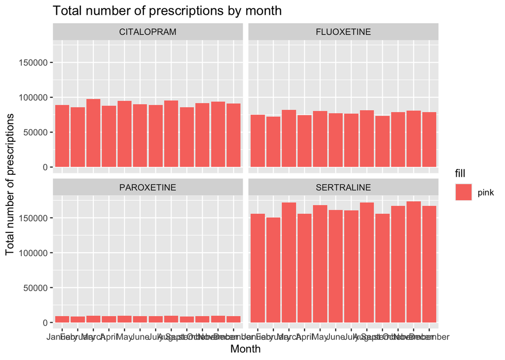

```r
SAD_datatidy %>%
  group_by(PaidDateMonth, DrugCategory) %>%
  summarise(total_prescriptions = sum(NumberOfPaidItems)) %>%
  ggplot(aes(x = PaidDateMonth, y = total_prescriptions)) +
  geom_col() +
  labs(title = "Total number of prescriptions by month",
       x = "Month",
       y = "Total number of prescriptions")+
  aes(fill = "pink") +
  facet_wrap(vars(DrugCategory))
```

## table showing the number of prescriptions of each drug by month

```r
SAD_datatidy %>%
  group_by(PaidDateMonth, DrugCategory) %>%
  summarise(total_prescriptions = sum(NumberOfPaidItems)) %>%
  gt()
```

| DrugCategory | total_prescriptions |
| --- | --- |
| January |  |
| CITALOPRAM | 88815 |
| FLUOXETINE | 75179 |
| PAROXETINE | 8968 |
| SERTRALINE | 155637 |
| February |  |
| CITALOPRAM | 85678 |
| FLUOXETINE | 72282 |
| PAROXETINE | 8520 |
| SERTRALINE | 150361 |
| March |  |
| CITALOPRAM | 97349 |
| FLUOXETINE | 82122 |
| PAROXETINE | 9698 |
| SERTRALINE | 172028 |
| April |  |
| CITALOPRAM | 88000 |
| FLUOXETINE | 74602 |
| PAROXETINE | 8862 |
| SERTRALINE | 155972 |
| May |  |
| CITALOPRAM | 94652 |
| FLUOXETINE | 80187 |
| PAROXETINE | 9475 |
| SERTRALINE | 168066 |
| June |  |
| CITALOPRAM | 90107 |
| FLUOXETINE | 76983 |
| PAROXETINE | 9167 |
| SERTRALINE | 161448 |
| July |  |
| CITALOPRAM | 89133 |
| FLUOXETINE | 76532 |
| PAROXETINE | 9128 |
| SERTRALINE | 160499 |
| August |  |
| CITALOPRAM | 95296 |
| FLUOXETINE | 81232 |
| PAROXETINE | 9501 |
| SERTRALINE | 172020 |
| September |  |
| CITALOPRAM | 85967 |
| FLUOXETINE | 73629 |
| PAROXETINE | 8725 |
| SERTRALINE | 155761 |
| October |  |
| CITALOPRAM | 91693 |
| FLUOXETINE | 78561 |
| PAROXETINE | 9190 |
| SERTRALINE | 167171 |
| November |  |
| CITALOPRAM | 93770 |
| FLUOXETINE | 81113 |
| PAROXETINE | 9595 |
| SERTRALINE | 173296 |
| December |  |
| CITALOPRAM | 91048 |
| FLUOXETINE | 78643 |
| PAROXETINE | 9187 |
| SERTRALINE | 166926 |